# Bulk RNA-seq Differential Expression and Pathway Analysis Report

Bioinformatics Analysis Service 2026-05-17

# 1. Executive Summary

This report presents a bulk RNA-seq analysis of MCF-7 breast cancer cells cocultured with adipose-derived stem cells (ADSCs) to investigate transcriptional changes induced by tumor microenvironment interactions.

The analysis identifies key molecular programs involving extracellular matrix remodeling, metabolic reprogramming, hypoxia response, and activation of pro-growth signaling pathways.

Overall, the results highlight potential prognostic biomarkers and provide insights into tumor–stroma interactions driving breast cancer progression.

# 2. Experimental Design

The dataset consists of 6 RNA-seq samples:

| Condition | Replicates | Description |
| --- | --- | --- |
| Control | 3 | MCF-7 cells cultured alone |
| ADSC | 3 | MCF-7 cells cocultured with ADSCs |

No batch effects were reported unless otherwise specified.

# 3. Data Processing Workflow

RNA-seq preprocessing was performed using a standard pipeline:

- Quality control: FastQC / MultiQC
- Adapter trimming: Trimmomatic
- Alignment: HISAT2
- Gene quantification: featureCounts

Raw counts were used for downstream statistical analysis.

Analysis was performed following established Bioconductor workflows for bulk RNA-seq differential expression analysis, ensuring reproducibility, analytical transparency, and adherence to widely accepted computational standards.

## 3.1 Statistical framework

Differential expression analysis was performed using edgeR, which models count data using a negative binomial distribution. Library normalization was performed using the TMM method to account for compositional differences between samples.

Statistical significance was defined using the false discovery rate (FDR) framework to control for multiple hypothesis testing.

# 4. Exploratory Data Analysis (EDA)

## 4.1 Principal Component Analysis (PCA)

PCA was used to assess global transcriptional differences between conditions.

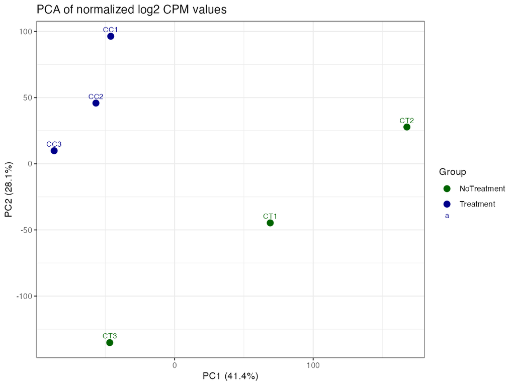

## 4.2 Sample Clustering

Sample-distance heatmap was performed to assess sample similarity.

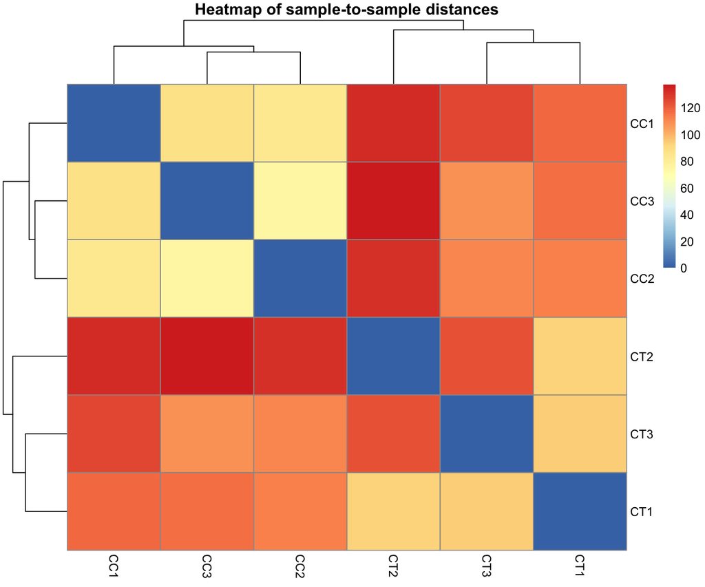

# 5. Differential Expression Analysis (DEGs)

Differential expression analysis was performed using edgeR with TMM normalization.

**Criteria for significance:**

```
## - FDR < 0.05

## - |log2FC| > 1
```

## 5.1 Summary of DEGs

```
## Total DEGs identified: 1013

## Upregulated genes: 887

## Downregulated genes: 126
```

## 5.2 Volcano Plot of DEGs

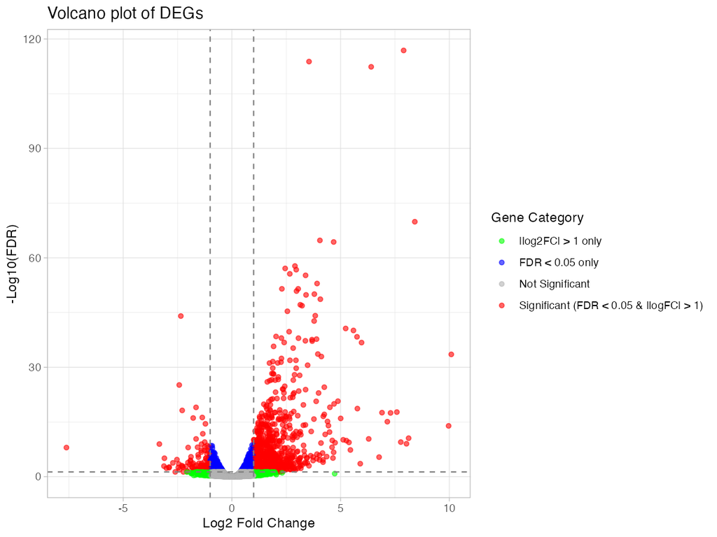

## 5.3 Heatmap of DEGs

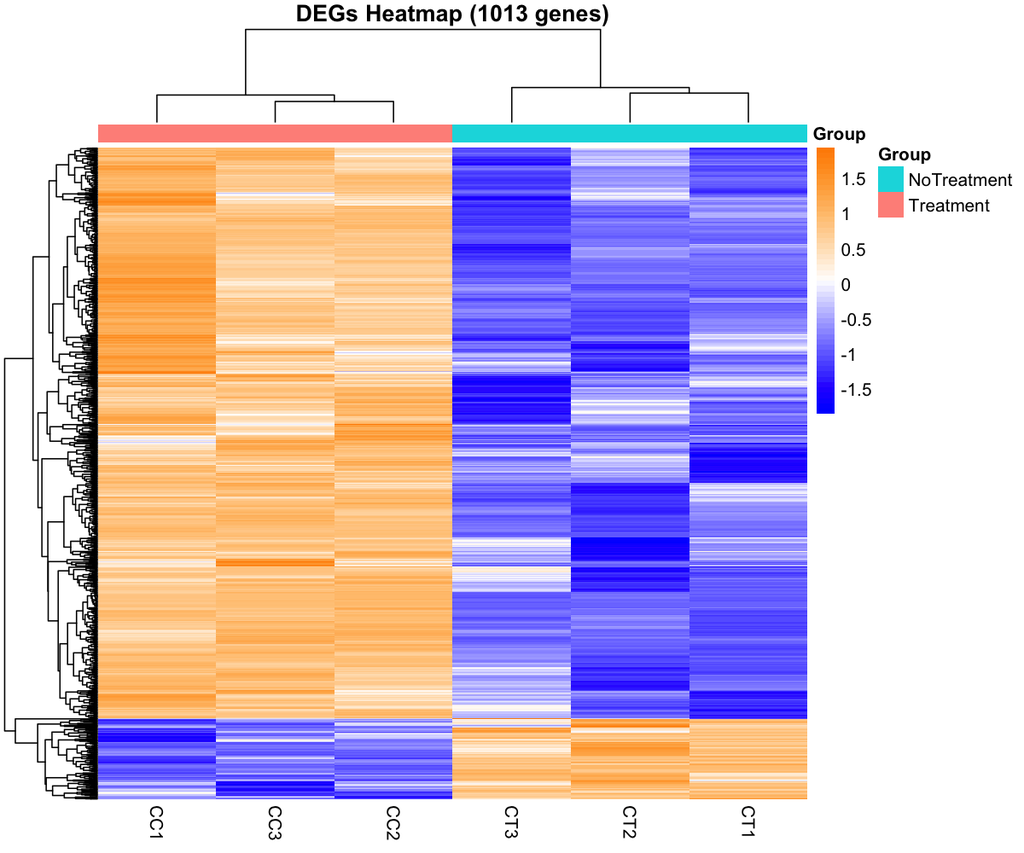

# 6. Functional Enrichment Analysis (ORA)

Functional enrichment analysis was performed using GO, KEGG, Reactome, and GSEA.

## 6.1 Gene Ontology terms

### **Biological Process**

- Response to hypoxia
- Extracellular matrix organization
- Cellular response to oxygen levels

### **Molecular Functions**

- Extracellular matrix structural constituent
- Monosaccharide binding
- Oxidoreductase activity

### **Cellular Component**

- Vesicle lumen
- Basement membrane
- Extracellular matrix

[figure not shown]

## Biological interpretation (GO enrichment)

The GO enrichment analysis highlights a coordinated transcriptional response involving hypoxia signaling, extracellular matrix remodeling, and metabolic adaptation. The enrichment of response to hypoxia and cellular response to oxygen levels suggests activation of oxygen-sensing pathways consistent with tumor microenvironment stress conditions.

In parallel, extracellular matrix organization and related structural components indicate active remodeling of the tumor microenvironment, a key feature associated with increased cell adhesion, migration, and stromal interaction in breast cancer progression.

At the molecular level, enrichment of extracellular matrix structural components and oxidoreductase activity reflects extracellular remodeling processes coupled with metabolic and redox adaptation. Finally, the presence of extracellular and vesicle-associated compartments supports enhanced intercellular communication within the tumor microenvironment.

Overall, these results are consistent with early pro-tumorigenic transcriptional reprogramming driven by stromal interaction, as described in ADSC-cocultured MCF-7 models.

## 6.2 KEGG Pathways

Significant pathways include:

- HIF-1 signaling pathway
- Glycolysis / gluconeogenesis
- Complement and coagulation cascades

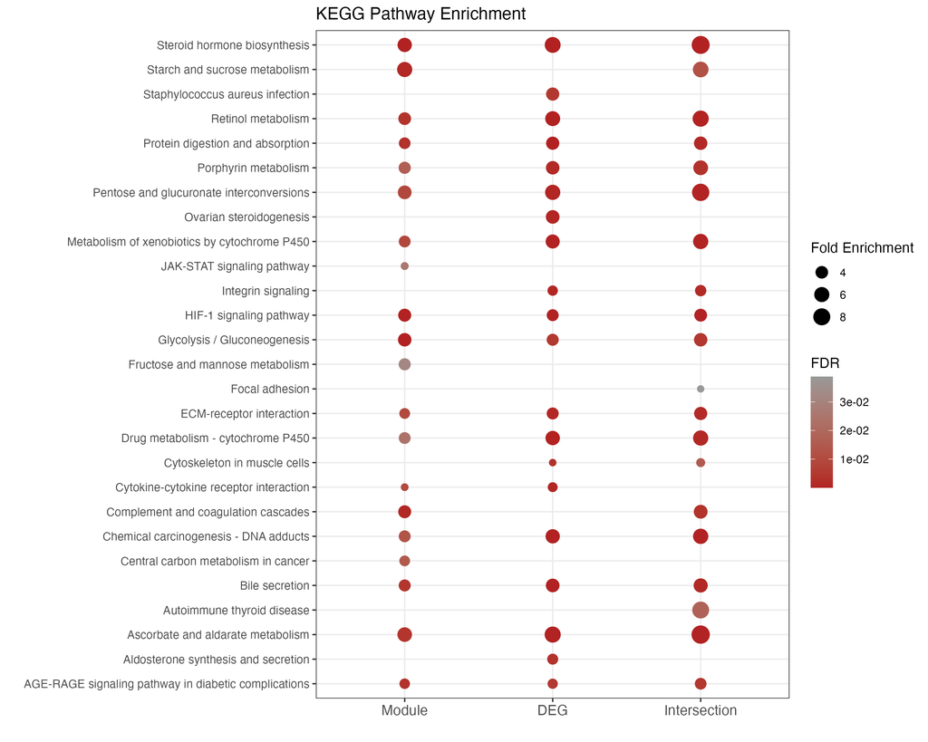

## 6.3 Reactome Pathways

- Interleukin-4 and Interleukin-13 signaling
- Fibronectin matrix formation
- Assembly of collagen fibrils and other multimeric structures

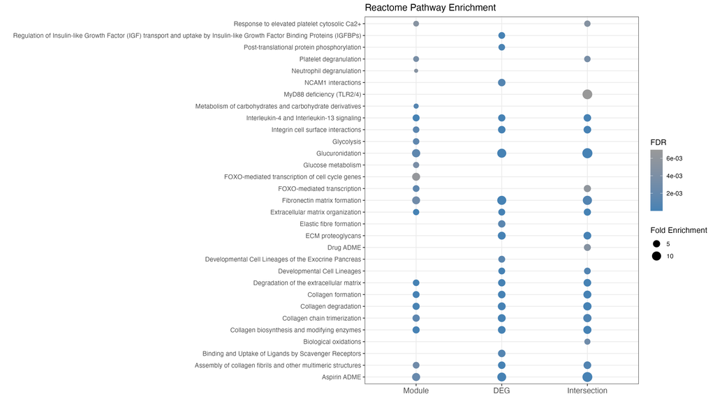

## Biological interpretation (KEGG and Reactome pathway)

The KEGG and Reactome enrichment analyses consistently highlight major biological processes associated with tumor microenvironment remodeling and metabolic adaptation. The enrichment of the HIF-1 signaling pathway together with glycolysis/gluconeogenesis suggests a metabolic shift toward hypoxia-driven glycolytic reprogramming, a well-established feature of early tumor progression and cellular adaptation to low oxygen conditions.

In parallel, pathways such as ECM-receptor interaction, fibronectin matrix formation, and collagen organization indicate strong extracellular matrix remodeling and reorganization of cell–matrix interactions, supporting increased cell adhesion, migration, and stromal communication.

Additionally, the activation of immune-related pathways, including complement and coagulation cascades and interleukin-4/13 signaling, suggests a pro-inflammatory microenvironment potentially driven by stromal–tumor crosstalk.

Overall, these pathways converge on a biological program characterized by hypoxia adaptation, metabolic reprogramming, and extracellular matrix remodeling, consistent with ADSC-induced pro-tumorigenic transcriptional changes in MCF-7 cells.

# 7.Gene Set Enrichment Analysis (GSEA)

Gene Set Enrichment Analysis (GSEA) was performed to evaluate coordinated expression changes across biologically relevant pathways without applying an arbitrary differential expression threshold. The analysis highlighted significant enrichment of pathways associated with hypoxia signaling, glycolytic metabolism, and oxidative phosphorylation, supporting widespread metabolic reprogramming in ADSC-treated MCF-7 cells.

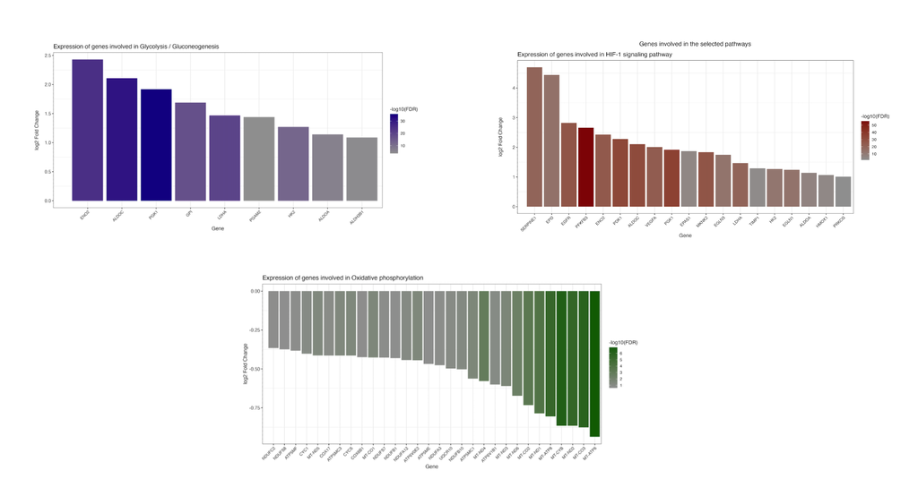

## Biological interpretation (GSEA)

Gene Set Enrichment Analysis (GSEA) further supported the presence of coordinated pathway-level transcriptional reprogramming associated with tumor microenvironment interactions.

Significant enrichment of HIF-1 signaling, glycolysis/gluconeogenesis, and oxidative phosphorylation pathways indicates extensive metabolic adaptation and energetic rewiring in ADSC-treated MCF-7 cells. These findings suggest activation of both hypoxia-responsive programs and altered cellular energy metabolism, consistent with stress adaptation and increased tumor cell plasticity.

Several highly contributing genes within these pathways are known to regulate glucose metabolism, mitochondrial activity, and cellular survival under hypoxic conditions, supporting the emergence of a metabolically flexible and potentially more aggressive phenotype.

Together, the GSEA results complement the ORA findings by demonstrating that ADSC-induced transcriptional changes occur not only at the level of individual differentially expressed genes, but also as coordinated activation of biologically interconnected signaling and metabolic programs.

# 8. Network Analysis

Protein-protein interaction (PPI) analysis was performed using STRING database.

Hub genes were identified using network topology analysis (cytoHubba MCC method)

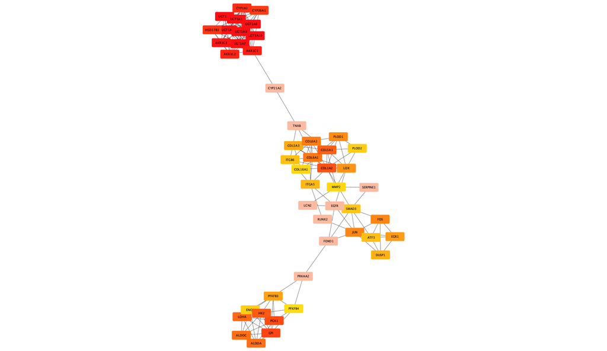

# 9. Clinical Validation

To evaluate the clinical relevance of the identified hub genes, survival-based analyses were performed using independent breast cancer cohorts.

Overall survival analysis was performed using TCGA-BRCA clinical and transcriptomic data. Kaplan–Meier survival modeling and Cox proportional hazards regression were used to evaluate prognostic associations.

Results indicate that specific hub genes identified from network analysis are associated with patient survival outcomes, supporting their potential role as prognostic biomarkers in breast cancer.

## 9.1 Hub Gene Expression Stratification by Estrogen Receptor (ER) Status in Breast Cancer Cohorts

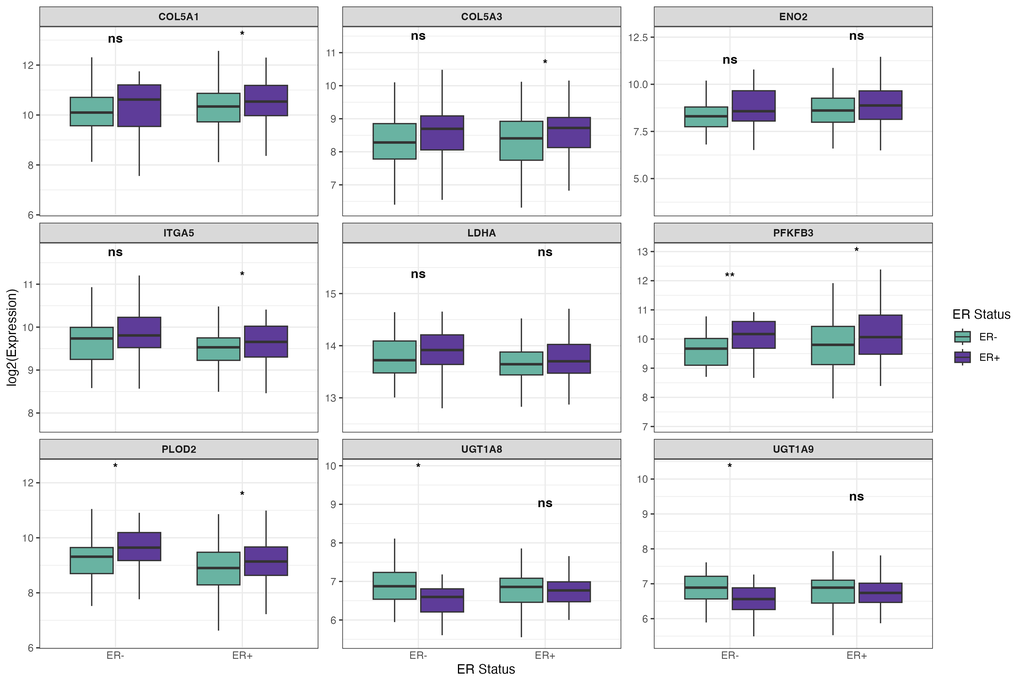

## 9.2 Overall Survival Analysis of PGK1 Expression in Breast Cancer (Kaplan–Meier Curve)

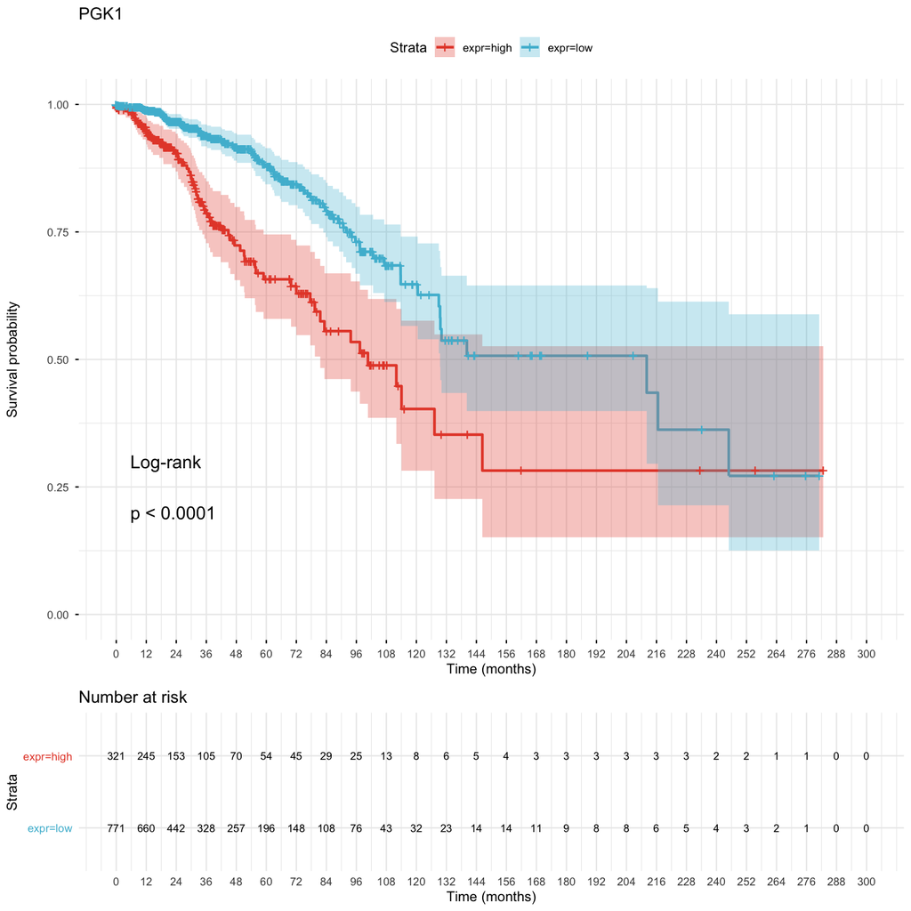

# 10. Integrated Biological Interpretation

The transcriptional profile of ADSC-treated MCF-7 cells reveals coordinated changes across extracellular matrix organization, metabolic reprogramming, hypoxia response, and pro-growth signaling pathways.

These alterations suggest a tumor microenvironment-driven shift toward increased cellular plasticity, enhanced migratory potential, and metabolic adaptation under stress conditions, consistent with early mechanisms of breast cancer progression.

Overall, ADSC coculture induces a pro-tumorigenic transcriptional program in MCF-7 cells with both mechanistic and clinically relevant implications.

# 11. Conclusions

# 12. Reproducibility

- R version: v.4.5.1
- Main Packages: edgeR, clusterProfiler, ReactomePA, fgsea, WGCNA, survival, survminer
- Session information available upon request
- Recommended: use renv for environment reconstruction

# 13. Study limitations and considerations

This analysis is based on a limited sample size (n = 3 per group), which is common in RNA-seq experimental designs but may limit statistical power for detecting low-effect genes.

Differential expression analysis was performed using edgeR, which assumes negative binomial distribution and is robust for small sample sizes, but results should be interpreted in the context of biological variability.

No batch effects were detected or reported; however, batch correction methods (e.g., surrogate variable analysis) may be required in more complex experimental designs.

Functional enrichment results depend on existing pathway annotations and should be interpreted as hypothesis-generating rather than definitive biological conclusions

Survival analyses (GEO disease-free survival and TCGA overall survival) are based on retrospective cohorts and may be influenced by clinical confounders and cohort heterogeneity; therefore, prognostic associations should be interpreted as exploratory and require independent validation.

# 14. Deliverables (client-ready output)

This analysis provides structured outputs designed for downstream interpretation and decision-making, including:

# 15. Biological and translational relevance

The observed transcriptional changes reflect key features of tumor microenvironment-driven cancer progression, including extracellular matrix remodeling, hypoxia adaptation, and metabolic reprogramming.

These processes are consistent with features associated with increased tumor aggressiveness and may provide insights into early molecular events linked to breast cancer progression in stromal-rich environments.

Rather than isolated pathway effects, the results indicate a coordinated tumor microenvironment-driven transcriptional program organized into three functional biological modules:

1. **Microenvironment remodeling module** (ECM organization, integrin signaling, collagen formation)
2. **Metabolic adaptation module** (HIF-1 signaling, glycolysis, oxidative stress response)
3. **Immune-stromal communication module** (cytokine signaling, complement activation, JAK-STAT pathway)

These findings may provide actionable insights into stromal–tumor interactions and could help prioritize candidate pathways for further experimental validation or therapeutic targeting.

# 16. Potential applications

This type of analysis can support:

- Biomarker discovery for cancer progression studies
- Identification of therapeutic targets in tumor microenvironment interactions
- Functional characterization of treatment-induced transcriptional changes
- Preclinical hypothesis generation for breast cancer research
- Integration with proteomics or clinical datasets for multi-omics analysis
- Prognostic biomarker identification based on disease-free and overall survival associations